# Workout Quality

Shivam Patel

8/1/2017

# Intro

Using devices such as Jawbone Up, Nike FuelBand, and Fitbit it is now possible to collect a large amount of data about personal activity relatively inexpensively. These type of devices are part of the quantified self movement – a group of enthusiasts who take measurements about themselves regularly to improve their health, to find patterns in their behavior, or because they are tech geeks. One thing that people regularly do is quantify how much of a particular activity they do, but they rarely quantify how well they do it. In this project, your goal will be to use data from accelerometers on the belt, forearm, arm, and dumbell of 6 participants. They were asked to perform barbell lifts correctly and incorrectly in 5 different ways. More information is available from the website here: http://groupware.les.inf.puc-rio.br/har (see the section on the Weight Lifting Exercise Dataset).

# Data

The training data for this project are available here:

https://d396qusza40orc.cloudfront.net/predmachlearn/pml-training.csv

The test data are available here:

https://d396qusza40orc.cloudfront.net/predmachlearn/pml-testing.csv

The data for this project come from this source: http://groupware.les.inf.puc-rio.br/har. If you use the document you create for this class for any purpose please cite them as they have been very generous in allowing their data to be used for this kind of assignment.

```r
training <- read.csv("pml-training.csv")
testing <- read.csv("pml-testing.csv")

dim(training)
```

```
## [1] 19622   160
```

```r
dim(testing)
```

```
## [1]  20 160
```

### Exploration

```r
str(training)
```

```
## 'data.frame':    19622 obs. of  160 variables:
##  $ X                       : int  1 2 3 4 5 6 7 8 9 10 ...
##  $ user_name               : Factor w/ 6 levels "adelmo","carlitos",..: 2 2 2 2 2 2 2 2 2 2 ...
##  $ raw_timestamp_part_1    : int  1323084231 1323084231 1323084231 1323084232 1323084232 1323084232 1323084232 1323084232 1323084232 1323084232 ...
##  $ raw_timestamp_part_2    : int  788290 808298 820366 120339 196328 304277 368296 440390 484323 484434 ...
##  $ cvtd_timestamp          : Factor w/ 20 levels "02/12/2011 13:32",..: 9 9 9 9 9 9 9 9 9 9 ...
##  $ new_window              : Factor w/ 2 levels "no","yes": 1 1 1 1 1 1 1 1 1 1 ...
##  $ num_window              : int  11 11 11 12 12 12 12 12 12 12 ...
##  $ roll_belt               : num  1.41 1.41 1.42 1.48 1.48 1.45 1.42 1.42 1.43 1.45 ...
##  $ pitch_belt              : num  8.07 8.07 8.07 8.05 8.07 8.06 8.09 8.13 8.16 8.17 ...
##  $ yaw_belt                : num  -94.4 -94.4 -94.4 -94.4 -94.4 -94.4 -94.4 -94.4 -94.4 -94.4 ...
##  $ total_accel_belt        : int  3 3 3 3 3 3 3 3 3 3 ...
##  $ kurtosis_roll_belt      : Factor w/ 397 levels "","-0.016850",..: 1 1 1 1 1 1 1 1 1 1 ...
##  $ kurtosis_picth_belt     : Factor w/ 317 levels "","-0.021887",..: 1 1 1 1 1 1 1 1 1 1 ...
##  $ kurtosis_yaw_belt       : Factor w/ 2 levels "","#DIV/0!": 1 1 1 1 1 1 1 1 1 1 ...
```

[output cut: 86 more lines]

We can already see that we need to clean the data and remove the columns that are mostly NA/empty strings.

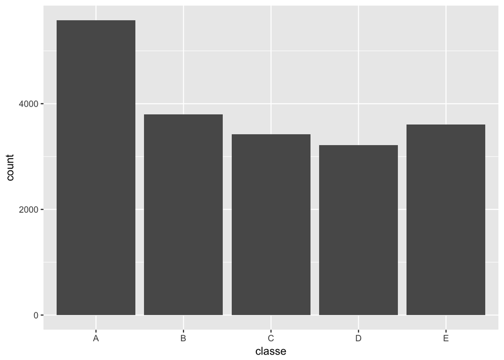

```r
library(ggplot2)
ggplot(training, aes(classe)) + geom_histogram(stat="count")
```

### Preprocessing

We get reid of the first 7 columns because they mainly contain user info that shouldnt be used to predict the quality of the workout.

```r
training = training[, 8:ncol(training)]
```

Before we remove any other columns, first lets calulate the percent na and percent empty strings for each column and analyze those that don’t equal 0 (missing at least 1 value)

```r
dropped_cols = data.frame()
for (col_name in colnames(training)) {
    col = training[, col_name]
    percent_na = sum(is.na(col))/length(col)
    percent_empty = sum(col == "")/length(col)
    if (percent_na != 0 | percent_empty != 0) {
        dropped_cols = rbind(dropped_cols, data.frame(col_name=col_name,
                                                      percent_na=percent_na,
                                                      percent_empty=percent_empty))
    }
}
dropped_cols
```

```
##                     col_name percent_na percent_empty
## 1         kurtosis_roll_belt  0.0000000     0.9793089
## 2        kurtosis_picth_belt  0.0000000     0.9793089
## 3          kurtosis_yaw_belt  0.0000000     0.9793089
## 4         skewness_roll_belt  0.0000000     0.9793089
## 5       skewness_roll_belt.1  0.0000000     0.9793089
## 6          skewness_yaw_belt  0.0000000     0.9793089
## 7              max_roll_belt  0.9793089            NA
## 8             max_picth_belt  0.9793089            NA
## 9               max_yaw_belt  0.0000000     0.9793089
## 10             min_roll_belt  0.9793089            NA
## 11            min_pitch_belt  0.9793089            NA
## 12              min_yaw_belt  0.0000000     0.9793089
## 13       amplitude_roll_belt  0.9793089            NA
## 14      amplitude_pitch_belt  0.9793089            NA
```

[output cut: 86 more lines]

Taking a look through this, whenever there is a missing value about 97% of the entire column is missing. So we’re going to remove them from our data.

```r
training = training[, !colnames(training) %in% dropped_cols$col_name]
```

# Modeling

### Create cross validation set

We want to split our training set so we can cross validate our model and make any final changes before we apply it to our test set (which only contains 20 rows).

```r
library(caret)
set.seed(40317)
inTrain <- createDataPartition(y=training$classe, p=0.8, list=FALSE)
cross_val <- training[-inTrain, ]
training <- training[inTrain, ]

dim(training)
```

```
## [1] 15699    53
```

```r
dim(cross_val)
```

```
## [1] 3923   53
```

### RPart

Your first model should always be something simple whether its linear regression or recursive partitioning. We are going to use the latter because of the classifcation nature of this project.

```r
rpart.fit <- train(classe~., data=training, method="rpart")
rpart.fit["finalModel"]
```

```
## $finalModel
## n= 15699
##
## node), split, n, loss, yval, (yprob)
##       * denotes terminal node
##
##  1) root 15699 11235 A (0.28 0.19 0.17 0.16 0.18)
##    2) roll_belt< 130.5 14368  9916 A (0.31 0.21 0.19 0.18 0.11)
##      4) pitch_forearm< -33.95 1257     9 A (0.99 0.0072 0 0 0) *
##      5) pitch_forearm>=-33.95 13111  9907 A (0.24 0.23 0.21 0.2 0.12)
##       10) magnet_dumbbell_y< 439.5 11100  7960 A (0.28 0.18 0.24 0.19 0.11)
##         20) roll_forearm< 123.5 6922  4109 A (0.41 0.18 0.18 0.17 0.06) *
##         21) roll_forearm>=123.5 4178  2797 C (0.078 0.17 0.33 0.23 0.19) *
##       11) magnet_dumbbell_y>=439.5 2011   986 B (0.032 0.51 0.045 0.23 0.19) *
##    3) roll_belt>=130.5 1331    12 E (0.009 0 0 0 0.99) *
```

From the summary of the final model, we can already see this isn’t going to work out because it doesn’t create any rules to classify D.

```r
rpart.probs <- predict(rpart.fit, cross_val)
confusionMatrix(rpart.probs, cross_val$classe)
```

```
## Confusion Matrix and Statistics
##
##           Reference
## Prediction    A    B    C    D    E
##          A 1019  296  320  295  112
##          B   17  261   18  112  110
##          C   78  202  346  236  187
##          D    0    0    0    0    0
##          E    2    0    0    0  312
##
## Overall Statistics
##
##                Accuracy : 0.494
##                  95% CI : (0.4782, 0.5098)
##     No Information Rate : 0.2845
##     P-Value [Acc > NIR] : < 2.2e-16
##
##                   Kappa : 0.3386
##  Mcnemar's Test P-Value : NA
##
## Statistics by Class:
##
##                      Class: A Class: B Class: C Class: D Class: E
## Sensitivity            0.9131  0.34387   0.5058   0.0000  0.43273
## Specificity            0.6356  0.91877   0.7830   1.0000  0.99938
## Pos Pred Value         0.4990  0.50386   0.3298      NaN  0.99363
## Neg Pred Value         0.9484  0.85374   0.8824   0.8361  0.88667
## Prevalence             0.2845  0.19347   0.1744   0.1639  0.18379
## Detection Rate         0.2598  0.06653   0.0882   0.0000  0.07953
## Detection Prevalence   0.5205  0.13204   0.2674   0.0000  0.08004
## Balanced Accuracy      0.7743  0.63132   0.6444   0.5000  0.71605
```

As we predicted, the results we sub par and so we move on to another modeling technique.

### Random Forest

```r
rf.fit <- train(classe~., data=training, method="rf")
summary(rf.fit)
```

```
##                 Length Class      Mode
## call                4  -none-     call
## type                1  -none-     character
## predicted       15699  factor     numeric
## err.rate         3000  -none-     numeric
## confusion          30  -none-     numeric
## votes           78495  matrix     numeric
## oob.times       15699  -none-     numeric
## classes             5  -none-     character
## importance         52  -none-     numeric
## importanceSD        0  -none-     NULL
## localImportance     0  -none-     NULL
## proximity           0  -none-     NULL
## ntree               1  -none-     numeric
## mtry                1  -none-     numeric
## forest             14  -none-     list
## y               15699  factor     numeric
## test                0  -none-     NULL
## inbag               0  -none-     NULL
## xNames             52  -none-     character
## problemType         1  -none-     character
## tuneValue           1  data.frame list
## obsLevels           5  -none-     character
## param               0  -none-     list
```

```r
rf.probs <- predict(rf.fit, cross_val)
confusionMatrix(rf.probs, cross_val$classe)
```

```
## Confusion Matrix and Statistics
##
##           Reference
## Prediction    A    B    C    D    E
##          A 1113    8    0    0    0
##          B    1  751    2    0    0
##          C    1    0  681    8    6
##          D    0    0    1  633    4
##          E    1    0    0    2  711
##
## Overall Statistics
##
##                Accuracy : 0.9913
##                  95% CI : (0.9879, 0.994)
##     No Information Rate : 0.2845
##     P-Value [Acc > NIR] : < 2.2e-16
##
##                   Kappa : 0.989
##  Mcnemar's Test P-Value : NA
##
## Statistics by Class:
##
##                      Class: A Class: B Class: C Class: D Class: E
## Sensitivity            0.9973   0.9895   0.9956   0.9844   0.9861
## Specificity            0.9971   0.9991   0.9954   0.9985   0.9991
## Pos Pred Value         0.9929   0.9960   0.9784   0.9922   0.9958
## Neg Pred Value         0.9989   0.9975   0.9991   0.9970   0.9969
## Prevalence             0.2845   0.1935   0.1744   0.1639   0.1838
## Detection Rate         0.2837   0.1914   0.1736   0.1614   0.1812
## Detection Prevalence   0.2858   0.1922   0.1774   0.1626   0.1820
## Balanced Accuracy      0.9972   0.9943   0.9955   0.9915   0.9926
```

Our results are very close to perfect so we can stop here.

# Results

```r
predict(rf.fit, testing)
```

```
##  [1] B A B A A E D B A A B C B A E E A B B B
## Levels: A B C D E
```

### Error

Even with these results there is still some amount of error involved but from our accuracy, it is so close to 100% that we need not be worried.